# final-project-1202

### About Dataset ([Kaggle Dataset Link](https://www.kaggle.com/datasets/teamincribo/cyber-security-attacks/data))

1. Timestamp: The time at which the network activity occurred.
2. Source IP Address: The IP address of the sender or initiator of the network traffic.
3. Destination IP Address: The IP address of the receiver or target of the network traffic.
4. Source Port: The port number used by the source IP address.
5. Destination Port: The port number used by the destination IP address.
6. Protocol: The communication protocol used (e.g., TCP, UDP, ICMP).
7. Packet Length: The size of the packet in bytes.
8. Packet Type: Type of packet (e.g., data packet, control packet).
9. Traffic Type: The type of traffic (e.g., web traffic, email traffic).
10. Payload Data: The actual data transmitted in the packet.
11. Malware Indicators: Indicators of potentially malicious activity or presence of malware.
12. Anomaly Scores: Scores indicating deviations from expected behavior, used for anomaly detection.
13. Alerts/Warnings: Notifications or warnings generated by security systems or monitoring tools.
14. Attack Type: Type of attack detected or suspected (e.g., DDoS, SQL injection).
15. Attack Signature: Specific patterns or signatures associated with known attacks.
16. Action Taken: Actions performed in response to detected threats or anomalies.
17. Severity Level: The level of severity associated with an alert or event (e.g., low, medium, high).
18. User Information: Information about the user involved in the network activity.
19. Device Information: Information about the device involved in the network activity (e.g., device type, operating system).
20. Network Segment: The segment or subnet of the network where the activity occurred.
21. Geo-location Data: Geographical location information associated with IP addresses.
22. Proxy Information: Information about proxy servers involved in the network communication.
23. Firewall Logs: Logs generated by firewall devices indicating allowed or blocked traffic.
24. IDS/IPS Alerts: Alerts generated by Intrusion Detection Systems (IDS) or Intrusion Prevention Systems (IPS) indicating suspicious or malicious activity.
25. Log Source: The source or origin of the log entry (e.g., name of the logging system or device).

### Importing libraries

```python
import pandas as pd
import numpy as np
import matplotlib.pyplot as plt
import seaborn as sns
import math
import re

from sklearn.model_selection import GridSearchCV, StratifiedKFold, cross_validate, train_test_split
from sklearn.preprocessing import StandardScaler, LabelEncoder
from sklearn.ensemble import RandomForestClassifier
from sklearn.linear_model import LogisticRegression
from sklearn.tree import DecisionTreeClassifier
from sklearn.svm import SVC
from sklearn.metrics import confusion_matrix, roc_curve, auc, make_scorer, f1_score, precision_score, recall_score
from sklearn.metrics import classification_report, ConfusionMatrixDisplay
```

### Importing the dataset

```python
df = pd.read_csv('/kaggle/input/cybersecurity-attacks-dataset/cybersecurity_attacks.csv')
df.head(3)
```

|  | Timestamp | Source IP Address | Destination IP Address | Source Port | Destination Port | Protocol | Packet Length | Packet Type | Traffic Type | Payload Data | ... | Action Taken | Severity Level | User Information | Device Information | Network Segment | Geo-location Data | Proxy Information | Firewall Logs | IDS/IPS Alerts | Log Source |
| --- | --- | --- | --- | --- | --- | --- | --- | --- | --- | --- | --- | --- | --- | --- | --- | --- | --- | --- | --- | --- | --- |
| 0 | 2023-05-30 06:33:58 | 103.216.15.12 | 84.9.164.252 | 31225 | 17616 | ICMP | 503 | Data | HTTP | Qui natus odio asperiores nam. Optio nobis ius... | ... | Logged | Low | Reyansh Dugal | Mozilla/5.0 (compatible; MSIE 8.0; Windows NT ... | Segment A | Jamshedpur, Sikkim | 150.9.97.135 | Log Data | NaN | Server |
| 1 | 2020-08-26 07:08:30 | 78.199.217.198 | 66.191.137.154 | 17245 | 48166 | ICMP | 1174 | Data | HTTP | Aperiam quos modi officiis veritatis rem. Omni... | ... | Blocked | Low | Sumer Rana | Mozilla/5.0 (compatible; MSIE 8.0; Windows NT ... | Segment B | Bilaspur, Nagaland | NaN | Log Data | NaN | Firewall |
| 2 | 2022-11-13 08:23:25 | 63.79.210.48 | 198.219.82.17 | 16811 | 53600 | UDP | 306 | Control | HTTP | Perferendis sapiente vitae soluta. Hic delectu... | ... | Ignored | Low | Himmat Karpe | Mozilla/5.0 (compatible; MSIE 9.0; Windows NT ... | Segment C | Bokaro, Rajasthan | 114.133.48.179 | Log Data | Alert Data | Firewall |

3 rows × 25 columns

### EDA

```python
columns = df.columns
columns
```

```
Index(['Timestamp', 'Source IP Address', 'Destination IP Address',
       'Source Port', 'Destination Port', 'Protocol', 'Packet Length',
       'Packet Type', 'Traffic Type', 'Payload Data', 'Malware Indicators',
       'Anomaly Scores', 'Alerts/Warnings', 'Attack Type', 'Attack Signature',
       'Action Taken', 'Severity Level', 'User Information',
       'Device Information', 'Network Segment', 'Geo-location Data',
       'Proxy Information', 'Firewall Logs', 'IDS/IPS Alerts', 'Log Source'],
      dtype='object')
```

```python
df.shape
```

```
(40000, 25)
```

```python
df.dtypes
```

```
Timestamp                  object
Source IP Address          object
Destination IP Address     object
Source Port                 int64
Destination Port            int64
Protocol                   object
Packet Length               int64
Packet Type                object
Traffic Type               object
Payload Data               object
Malware Indicators         object
Anomaly Scores            float64
Alerts/Warnings            object
Attack Type                object
Attack Signature           object
Action Taken               object
Severity Level             object
User Information           object
Device Information         object
Network Segment            object
Geo-location Data          object
Proxy Information          object
Firewall Logs              object
IDS/IPS Alerts             object
Log Source                 object
dtype: object
```

```python
df.nunique()
```

```
Timestamp                 39997
Source IP Address         40000
Destination IP Address    40000
Source Port               29761
Destination Port          29895
Protocol                      3
Packet Length              1437
Packet Type                   2
Traffic Type                  3
Payload Data              40000
Malware Indicators            1
Anomaly Scores             9826
Alerts/Warnings               1
Attack Type                   3
Attack Signature              2
Action Taken                  3
Severity Level                3
User Information          32389
Device Information        32104
Network Segment               3
Geo-location Data          8723
Proxy Information         20148
Firewall Logs                 1
IDS/IPS Alerts                1
Log Source                    2
dtype: int64
```

```python
df.isna().sum()
```

```
Timestamp                     0
Source IP Address             0
Destination IP Address        0
Source Port                   0
Destination Port              0
Protocol                      0
Packet Length                 0
Packet Type                   0
Traffic Type                  0
Payload Data                  0
Malware Indicators        20000
Anomaly Scores                0
Alerts/Warnings           20067
Attack Type                   0
Attack Signature              0
Action Taken                  0
Severity Level                0
User Information              0
Device Information            0
Network Segment               0
Geo-location Data             0
Proxy Information         19851
Firewall Logs             19961
IDS/IPS Alerts            20050
Log Source                    0
dtype: int64
```

### Filling the missing values

```python
df['Malware Indicators'].value_counts(dropna = False)
df['Malware Indicators'] = df['Malware Indicators'].fillna('Not detected')
```

```python
df['Alerts/Warnings'].value_counts(dropna = False)
df['Alerts/Warnings'] = df['Alerts/Warnings'].fillna('No alerts')
```

```python
df['Proxy Information'].value_counts(dropna = False)
df['Proxy Information'] = df['Proxy Information'].fillna('No proxy')
```

```python
df['Firewall Logs'].value_counts(dropna = False)
df['Firewall Logs'] = df['Firewall Logs'].fillna('No logs')
```

```python
df['IDS/IPS Alerts'].value_counts(dropna = False)
df['IDS/IPS Alerts'] = df['IDS/IPS Alerts'].fillna('No alerts')
```

```python
df.isna().sum()
```

```
Timestamp                 0
Source IP Address         0
Destination IP Address    0
Source Port               0
Destination Port          0
Protocol                  0
Packet Length             0
Packet Type               0
Traffic Type              0
Payload Data              0
Malware Indicators        0
Anomaly Scores            0
Alerts/Warnings           0
Attack Type               0
Attack Signature          0
Action Taken              0
Severity Level            0
User Information          0
Device Information        0
Network Segment           0
Geo-location Data         0
Proxy Information         0
Firewall Logs             0
IDS/IPS Alerts            0
Log Source                0
dtype: int64
```

### Plotting charts and graphs

```python
df['Protocol'].value_counts()
```

```
Protocol
ICMP    13429
UDP     13299
TCP     13272
Name: count, dtype: int64
```

#### Most Common Attack Types

```python
attack_type_counts = pd.DataFrame(df['Attack Type'].value_counts())
attack_type_counts_df = pd.DataFrame(attack_type_counts).reset_index()
attack_type_counts_df.columns = ['Attack Type', 'Count of Attacks']
print(attack_type_counts_df)
```

```
  Attack Type  Count of Attacks
0        DDoS             13428
1     Malware             13307
2   Intrusion             13265
```

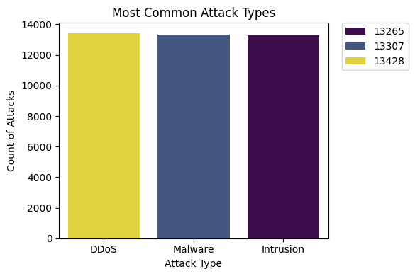

```python
# Plotting the top attack types
plt.figure(figsize=(6, 4))
sns.barplot(x='Attack Type', y='Count of Attacks', hue='Count of Attacks', data=attack_type_counts_df, palette='viridis', dodge=False)
plt.xlabel('Attack Type')
plt.ylabel('Count of Attacks')
plt.title('Most Common Attack Types')
plt.legend(bbox_to_anchor=(1.05, 1), loc=2, borderaxespad=0)
plt.tight_layout()
plt.show()
```

#### Top 15 Geographic Locations Source of Malicious Traffic

```python
geo_location_counts = pd.DataFrame(df['Geo-location Data'].value_counts())
geo_location_counts_df = pd.DataFrame(geo_location_counts).reset_index()
geo_location_counts_df.columns = ['Geo-location Data', 'Count of Attacks']
top_geo_attack_types = geo_location_counts_df.head(15)
print(top_geo_attack_types)
```

```
                          Geo-location Data  Count of Attacks
0                      Ghaziabad, Meghalaya                16
1                Kalyan-Dombivli, Jharkhand                15
2                    Ghaziabad, Uttarakhand                14
3                        Ghaziabad, Tripura                14
4            Yamunanagar, Arunachal Pradesh                13
5                        Kottayam, Nagaland                13
6                   Srikakulam, Uttarakhand                13
7                      Aurangabad, Nagaland                13
8                          Motihari, Odisha                13
9                            Amroha, Sikkim                13
10                     Ghaziabad, Jharkhand                13
11                         Patna, Karnataka                12
12                       Bally, Maharashtra                12
13  Raurkela Industrial Township, Jharkhand                12
14                    Jalna, Andhra Pradesh                12
```

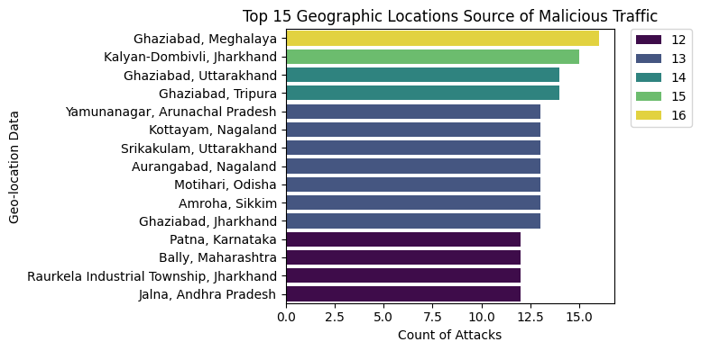

```python
# Plotting the top attack types
plt.figure(figsize=(8, 4))
sns.barplot(x='Count of Attacks', y='Geo-location Data', hue='Count of Attacks', data=top_geo_attack_types, palette='viridis', dodge=False)
plt.xlabel('Count of Attacks')
plt.ylabel('Geo-location Data')
plt.title('Top 15 Geographic Locations Source of Malicious Traffic')
plt.legend(bbox_to_anchor=(1.05, 1), loc=2, borderaxespad=0)
plt.tight_layout()
plt.show()
```

#### Top 20 Most Targeted Source Ports

```python
source_port_counts = pd.DataFrame(df['Source Port'].value_counts())
source_port_counts_df = pd.DataFrame(source_port_counts).reset_index()
source_port_counts_df.columns = ['Source Port', 'Count of Attacks']
top_source_port_attack_types = source_port_counts_df.head(20)
print(top_source_port_attack_types)
```

```
    Source Port  Count of Attacks
0         41341                 6
1         53397                 5
2         30175                 5
3         34763                 5
4         37135                 5
5         47259                 5
6         53790                 5
7         16784                 5
8          4779                 5
9          4239                 5
10         4622                 5
11        31656                 5
12         4128                 5
13        17916                 5
14        45874                 5
15        24528                 5
16        15669                 5
17        25710                 5
18        60026                 5
19         8653                 5
```

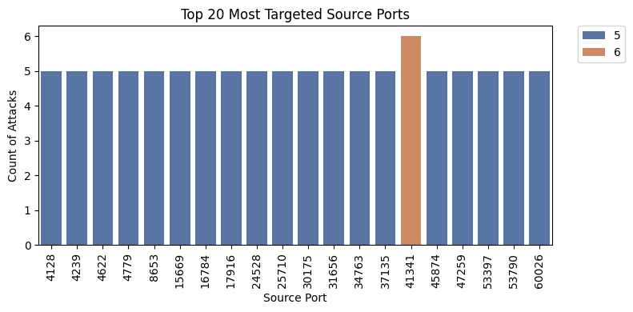

```python
# Plotting the top attack types
plt.figure(figsize=(8, 4))
sns.barplot(x='Source Port', y='Count of Attacks', hue='Count of Attacks', data=top_source_port_attack_types, palette='deep', dodge=False)
plt.xlabel('Source Port')
plt.ylabel('Count of Attacks')
plt.title('Top 20 Most Targeted Source Ports')
plt.legend(bbox_to_anchor=(1.05, 1), loc=2, borderaxespad=0)
plt.xticks(rotation=90)
plt.tight_layout()
plt.show()
```

```python
destination_port_counts = pd.DataFrame(df['Destination Port'].value_counts())
destination_port_counts_df = pd.DataFrame(destination_port_counts).reset_index()
destination_port_counts_df.columns = ['Destination Port', 'Count of Attacks']
top_destination_port_attack_types = destination_port_counts_df.head(20)
print(top_destination_port_attack_types)
```

```
    Destination Port  Count of Attacks
0              34117                 6
1               7508                 6
2              16503                 5
3               9565                 5
4              37248                 5
5              38787                 5
6              56672                 5
7              57508                 5
8              36756                 5
9              25889                 5
10             39887                 5
11             30449                 5
12             59207                 5
13             30804                 5
14             15150                 5
15              6871                 5
16             57516                 5
17             31724                 5
18             25350                 5
19             12585                 5
```

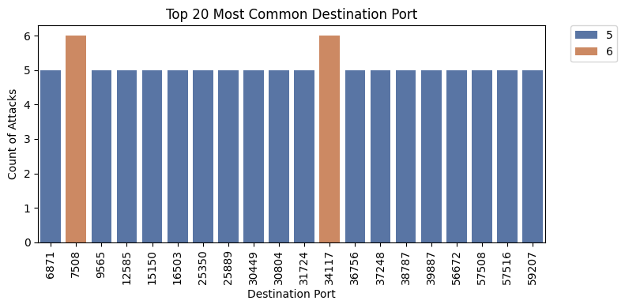

```python
# Plotting the top attack types
plt.figure(figsize=(8, 4))
sns.barplot(x='Destination Port', y='Count of Attacks', hue='Count of Attacks', data=top_destination_port_attack_types, palette='deep', dodge=False)
plt.xlabel('Destination Port')
plt.ylabel('Count of Attacks')
plt.title('Top 20 Most Common Destination Port')
plt.legend(bbox_to_anchor=(1.05, 1), loc=2, borderaxespad=0)
plt.xticks(rotation=90)
plt.tight_layout()
plt.show()
```

#### Protocols by Mean Severity Level

```python
severity_mapping = {'Low': 1, 'Medium': 2, 'High': 3}
df['Severity Level Numeric'] = df['Severity Level'].map(severity_mapping)

# Group by 'Protocol' and calculate the mean severity level
protocol_severity = df.groupby('Protocol')['Severity Level Numeric'].mean().reset_index()

# Sort the result by mean severity level
protocol_severity = protocol_severity.sort_values(by='Severity Level Numeric').round(3)
print(protocol_severity)
```

```
  Protocol  Severity Level Numeric
0     ICMP                   1.996
1      TCP                   2.006
2      UDP                   2.012
```

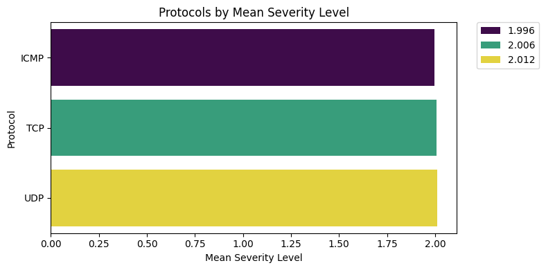

```python
# Plotting the top protocols by mean severity level
plt.figure(figsize=(8, 4))
sns.barplot(x='Severity Level Numeric', y='Protocol', hue='Severity Level Numeric', data=protocol_severity, palette='viridis', dodge=False)
plt.xlabel('Mean Severity Level')
plt.ylabel('Protocol')
plt.title('Protocols by Mean Severity Level')
plt.legend(bbox_to_anchor=(1.05, 1), loc=2, borderaxespad=0)
plt.tight_layout()
plt.show()
```

#### Creating month and year from timestamp

```python
# Changing string object to datetime object
df['Timestamp'] = pd.to_datetime(df['Timestamp'])
```

```python
# Adding month column
df['Month'] = df['Timestamp'].dt.month

# Adding year column
df['Year'] = df['Timestamp'].dt.year
```

#### Extracting browser and device/OS

```python
df['Device Information'].unique()
```

```
array(['Mozilla/5.0 (compatible; MSIE 8.0; Windows NT 6.2; Trident/5.0)',
       'Mozilla/5.0 (compatible; MSIE 8.0; Windows NT 6.0; Trident/4.0)',
       'Mozilla/5.0 (compatible; MSIE 9.0; Windows NT 6.2; Trident/5.0)',
       ...,
       'Mozilla/5.0 (Windows; U; Windows NT 4.0) AppleWebKit/533.2.3 (KHTML, like Gecko) Version/4.0.3 Safari/533.2.3',
       'Mozilla/5.0 (X11; Linux i686) AppleWebKit/536.2 (KHTML, like Gecko) Chrome/15.0.852.0 Safari/536.2',
       'Mozilla/5.0 (iPod; U; CPU iPhone OS 3_0 like Mac OS X; tg-TJ) AppleWebKit/534.33.5 (KHTML, like Gecko) Version/4.0.5 Mobile/8B116 Safari/6534.33.5'],
      dtype=object)
```

```python
# df['Device/OS'] = df['Device Information']
df['Browser'] = df['Device Information'].apply(lambda x: x.split('/')[0])
```

```python
patterns = [
    r'Windows',
    r'Linux',
    r'Android',
    r'iPad',
    r'iPod',
    r'iPhone',
    r'Macintosh',
]

# Function to find and print matching patterns
def find_matching_pattern(device_info):
    for pattern in patterns:
        if re.search(pattern, device_info, flags=re.IGNORECASE):
            return pattern

# Apply function to each row in 'Device Information' column
df['Device/OS']  = df['Device Information'].apply(find_matching_pattern)
```

```python
df.head(3)
```

|  | Timestamp | Source IP Address | Destination IP Address | Source Port | Destination Port | Protocol | Packet Length | Packet Type | Traffic Type | Payload Data | ... | Geo-location Data | Proxy Information | Firewall Logs | IDS/IPS Alerts | Log Source | Severity Level Numeric | Month | Year | Browser | Device/OS |
| --- | --- | --- | --- | --- | --- | --- | --- | --- | --- | --- | --- | --- | --- | --- | --- | --- | --- | --- | --- | --- | --- |
| 0 | 2023-05-30 06:33:58 | 103.216.15.12 | 84.9.164.252 | 31225 | 17616 | ICMP | 503 | Data | HTTP | Qui natus odio asperiores nam. Optio nobis ius... | ... | Jamshedpur, Sikkim | 150.9.97.135 | Log Data | No alerts | Server | 1 | 5 | 2023 | Mozilla | Windows |
| 1 | 2020-08-26 07:08:30 | 78.199.217.198 | 66.191.137.154 | 17245 | 48166 | ICMP | 1174 | Data | HTTP | Aperiam quos modi officiis veritatis rem. Omni... | ... | Bilaspur, Nagaland | No proxy | Log Data | No alerts | Firewall | 1 | 8 | 2020 | Mozilla | Windows |
| 2 | 2022-11-13 08:23:25 | 63.79.210.48 | 198.219.82.17 | 16811 | 53600 | UDP | 306 | Control | HTTP | Perferendis sapiente vitae soluta. Hic delectu... | ... | Bokaro, Rajasthan | 114.133.48.179 | Log Data | Alert Data | Firewall | 1 | 11 | 2022 | Mozilla | Windows |

3 rows × 30 columns

```python
df.loc[(df['Malware Indicators'] == 'IoC Detected') & (df['IDS/IPS Alerts'] == 'Alert Data') & (df['Attack Type'] == 'Malware')]
```

|  | Timestamp | Source IP Address | Destination IP Address | Source Port | Destination Port | Protocol | Packet Length | Packet Type | Traffic Type | Payload Data | ... | Geo-location Data | Proxy Information | Firewall Logs | IDS/IPS Alerts | Log Source | Severity Level Numeric | Month | Year | Browser | Device/OS |
| --- | --- | --- | --- | --- | --- | --- | --- | --- | --- | --- | --- | --- | --- | --- | --- | --- | --- | --- | --- | --- | --- |
| 21 | 2022-04-29 14:46:46 | 214.247.90.42 | 196.26.121.164 | 37998 | 1757 | UDP | 410 | Control | DNS | Architecto voluptatum delectus.\nAut quia fugi... | ... | Tadepalligudem, Rajasthan | No proxy | Log Data | Alert Data | Server | 1 | 4 | 2022 | Mozilla | Windows |
| 32 | 2020-10-15 19:05:37 | 99.8.190.190 | 91.166.229.253 | 12932 | 47900 | TCP | 373 | Data | DNS | Iste harum voluptas hic harum sapiente suscipi... | ... | Nellore, Tripura | No proxy | Log Data | Alert Data | Server | 2 | 10 | 2020 | Opera | Linux |
| 46 | 2023-05-16 13:01:56 | 170.211.138.30 | 172.97.181.148 | 25022 | 6593 | TCP | 554 | Control | DNS | Voluptate mollitia cupiditate necessitatibus n... | ... | Amravati, Kerala | 95.170.137.42 | Log Data | Alert Data | Firewall | 3 | 5 | 2023 | Mozilla | iPod |
| 48 | 2021-08-20 14:42:57 | 118.175.170.127 | 43.100.128.47 | 23934 | 57206 | TCP | 1378 | Control | DNS | Pariatur quia dolore praesentium. Ut dolorem n... | ... | Giridih, Chhattisgarh | 20.86.235.147 | Log Data | Alert Data | Firewall | 2 | 8 | 2021 | Mozilla | Windows |
| 54 | 2020-12-13 02:43:04 | 168.159.245.149 | 211.64.146.125 | 46895 | 63852 | TCP | 1224 | Data | HTTP | Molestias facilis maiores similique. Itaque do... | ... | Guntur, Tamil Nadu | No proxy | No logs | Alert Data | Server | 2 | 12 | 2020 | Mozilla | Linux |
| ... | ... | ... | ... | ... | ... | ... | ... | ... | ... | ... | ... | ... | ... | ... | ... | ... | ... | ... | ... | ... | ... |
| 39956 | 2022-06-17 02:41:11 | 205.9.232.102 | 57.3.168.6 | 8642 | 32255 | TCP | 714 | Control | HTTP | Quam provident enim nostrum. Officia ea cupidi... | ... | Maheshtala, Goa | 43.57.174.231 | Log Data | Alert Data | Server | 3 | 6 | 2022 | Mozilla | iPod |
| 39967 | 2020-05-25 06:21:28 | 197.14.66.2 | 170.242.248.216 | 30989 | 7176 | ICMP | 491 | Data | FTP | Quo soluta eos quisquam.\nLaboriosam maxime do... | ... | Morena, Assam | No proxy | No logs | Alert Data | Server | 1 | 5 | 2020 | Mozilla | iPod |
| 39973 | 2021-12-22 20:53:56 | 35.47.218.3 | 193.84.235.7 | 41254 | 21200 | UDP | 334 | Data | HTTP | A aperiam pariatur quisquam. Culpa repellat eo... | ... | Bhind, Meghalaya | No proxy | No logs | Alert Data | Server | 1 | 12 | 2021 | Mozilla | Linux |
| 39980 | 2021-07-01 19:09:43 | 113.228.203.251 | 9.92.96.13 | 56464 | 14589 | UDP | 1404 | Control | HTTP | Magni suscipit incidunt. Doloremque maxime nul... | ... | Latur, Madhya Pradesh | No proxy | No logs | Alert Data | Firewall | 1 | 7 | 2021 | Opera | Windows |
| 39987 | 2022-11-05 11:34:58 | 19.154.37.195 | 163.191.169.236 | 21994 | 29359 | ICMP | 248 | Control | DNS | Assumenda autem voluptatem aliquid ipsa. Unde ... | ... | Kanpur, Maharashtra | No proxy | Log Data | Alert Data | Server | 1 | 11 | 2022 | Opera | Windows |

3380 rows × 30 columns

#### Devices/OS Targeted by Attacks

```python
# Group by 'Device/OS' and count the number of attacks
device_counts = df['Device/OS'].value_counts()

# Convert the result to a DataFrame for better readability
device_counts_df = pd.DataFrame(device_counts).reset_index()
device_counts_df.columns = ['Device/OS', 'Count of Attacks']

# Display the devices/OS by number of attacks
print(device_counts_df)
```

```
   Device/OS  Count of Attacks
0    Windows             17953
1      Linux              8840
2  Macintosh              5813
3       iPod              2656
4    Android              1620
5     iPhone              1567
6       iPad              1551
```

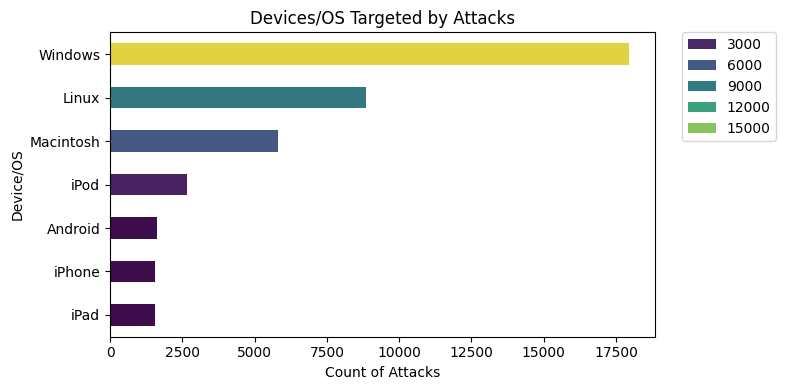

```python
# Plotting the top devices/OS
plt.figure(figsize=(8, 4))
sns.barplot(x='Count of Attacks', y='Device/OS', hue='Count of Attacks', data=device_counts_df, palette='viridis', dodge=False, width = 0.5)
plt.xlabel('Count of Attacks')
plt.ylabel('Device/OS')
plt.title('Devices/OS Targeted by Attacks')
plt.legend(bbox_to_anchor = (1.05, 1), loc = 2, borderaxespad = 0)
plt.tight_layout()
plt.show()
```

#### Browser vs Device/OS

```python
agg_data_browser = df.groupby(['Browser', 'Device/OS']).size().reset_index(name='Count')
print(agg_data_browser)
```

```
   Browser  Device/OS  Count
0  Mozilla    Android   1620
1  Mozilla      Linux   4799
2  Mozilla  Macintosh   5813
3  Mozilla    Windows  13945
4  Mozilla       iPad   1551
5  Mozilla     iPhone   1567
6  Mozilla       iPod   2656
7    Opera      Linux   4041
8    Opera    Windows   4008
```

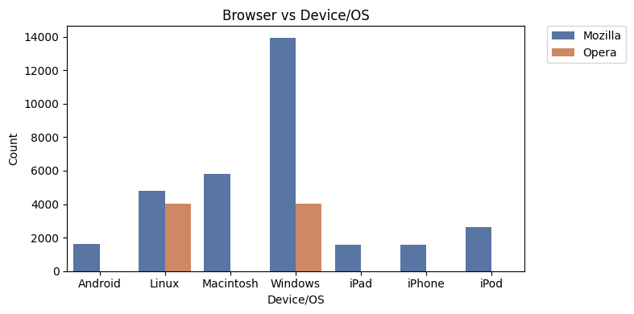

```python
plt.figure(figsize=(8, 4))
sns.barplot(x='Device/OS', y='Count', hue='Browser', data=agg_data_browser, palette='deep')
plt.xlabel('Device/OS')
plt.ylabel('Count')
plt.title('Browser vs Device/OS')
plt.legend(bbox_to_anchor=(1.05, 1), loc=2, borderaxespad=0)
plt.tight_layout()
plt.show()
```

#### Count of attacks per month

```python
attack_by_month = pd.DataFrame(df['Month'].value_counts())
attack_by_month_df = pd.DataFrame(attack_by_month).reset_index()
attack_by_month_df.columns = ['Month', 'Count of Attacks']
print(attack_by_month_df)
```

```
    Month  Count of Attacks
0       3              3678
1       7              3623
2       8              3615
3       6              3609
4       5              3595
5       9              3482
6       4              3421
7       1              3378
8       2              3232
9      10              2989
10     11              2703
11     12              2675
```

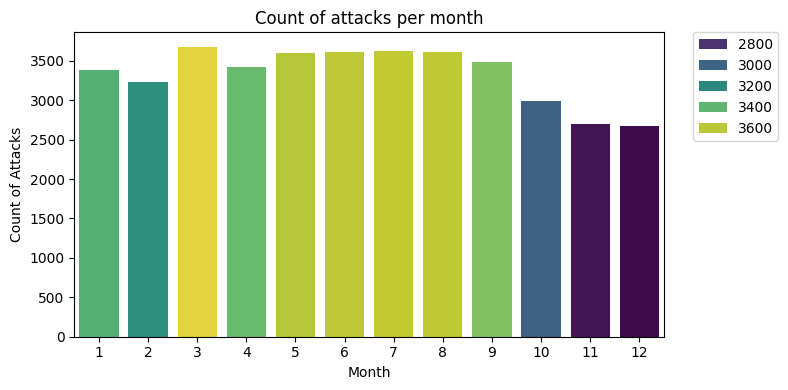

```python
# Plotting the top protocols by mean severity level
plt.figure(figsize=(8, 4))
sns.barplot(x='Month', y='Count of Attacks', hue='Count of Attacks', palette = 'viridis', data=attack_by_month_df)
plt.xlabel('Month')
plt.ylabel('Count of Attacks')
plt.title('Count of attacks per month')
plt.legend(bbox_to_anchor=(1.05, 1), loc=2, borderaxespad=0)
plt.tight_layout()
plt.show()
```

[figure not shown]

```python
# Plotting the top protocols by mean severity level
plt.figure(figsize=(12, 6))
sns.lineplot(x='Month', y='Anomaly Scores', hue='Malware Indicators', palette = 'viridis', data=df)
plt.xlabel('Month')
plt.ylabel('Count of Attacks')
plt.title('Count of attacks by month')
plt.legend(bbox_to_anchor=(1.05, 1), loc=2, borderaxespad=0)
plt.grid()
plt.tight_layout()
plt.show()
```

#### Count of attacks by year

```python
attack_by_year = pd.DataFrame(df['Year'].value_counts())
attack_by_year_df = pd.DataFrame(attack_by_year).reset_index()
attack_by_year_df.columns = ['Year', 'Count of Attacks']
print(attack_by_year_df)
```

```
   Year  Count of Attacks
0  2022             10750
1  2020             10573
2  2021             10538
3  2023              8139
```

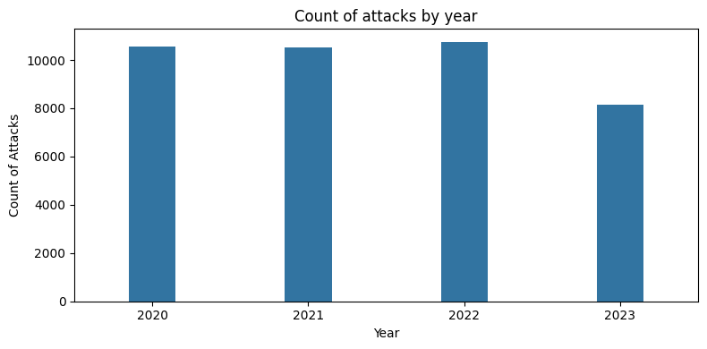

```python
# Plotting the top protocols by mean severity level
plt.figure(figsize=(8, 4))
sns.barplot(x='Year', y='Count of Attacks', data=attack_by_year_df, width = 0.3)
plt.xlabel('Year')
plt.ylabel('Count of Attacks')
plt.title('Count of attacks by year')
# plt.legend(bbox_to_anchor=(1.05, 1), loc=2, borderaxespad=0)
plt.tight_layout()
plt.show()
```

#### Count of attacks by year on attack type

```python
agg_data_attack_type = df.groupby(['Year', 'Attack Type']).size().reset_index(name='Count')
print(agg_data_attack_type)
```

```
    Year Attack Type  Count
0   2020        DDoS   3533
1   2020   Intrusion   3551
2   2020     Malware   3489
3   2021        DDoS   3545
4   2021   Intrusion   3475
5   2021     Malware   3518
6   2022        DDoS   3558
7   2022   Intrusion   3563
8   2022     Malware   3629
9   2023        DDoS   2792
10  2023   Intrusion   2676
11  2023     Malware   2671
```

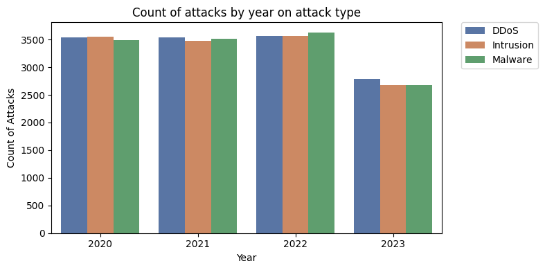

```python
plt.figure(figsize=(8, 4))
sns.barplot(x='Year', y='Count', hue='Attack Type', data=agg_data_attack_type, palette='deep')
plt.xlabel('Year')
plt.ylabel('Count of Attacks')
plt.title('Count of attacks by year on attack type')
plt.legend(bbox_to_anchor=(1.05, 1), loc=2, borderaxespad=0)
plt.tight_layout()
plt.show()
```

#### Count of Malicious Incidents by Traffic Type and Attack Type

```python
malicious_traffic = df.loc[df['Malware Indicators'] == 'IoC Detected']
# Group by 'Traffic Type' and count the number of occurrences
traffic_type_counts = malicious_traffic['Traffic Type'].value_counts()

# Convert the result to a DataFrame for better readability
traffic_type_counts_df = pd.DataFrame(traffic_type_counts).reset_index()
traffic_type_counts_df.columns = ['Traffic Type', 'Count of Malicious Incidents']
print(traffic_type_counts_df)
```

```
  Traffic Type  Count of Malicious Incidents
0         HTTP                          6721
1          DNS                          6644
2          FTP                          6635
```

```python
grouped_traffic_attack_type = df.groupby(['Traffic Type', 'Attack Type']).size().reset_index(name = 'Count')
grouped_traffic_attack_type
```

|  | Traffic Type | Attack Type | Count |
| --- | --- | --- | --- |
| 0 | DNS | DDoS | 4528 |
| 1 | DNS | Intrusion | 4426 |
| 2 | DNS | Malware | 4422 |
| 3 | FTP | DDoS | 4389 |
| 4 | FTP | Intrusion | 4453 |
| 5 | FTP | Malware | 4422 |
| 6 | HTTP | DDoS | 4511 |
| 7 | HTTP | Intrusion | 4386 |
| 8 | HTTP | Malware | 4463 |

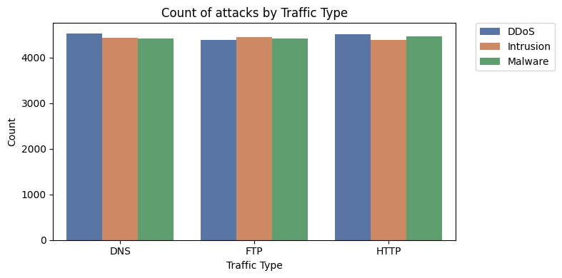

```python
plt.figure(figsize=(8, 4))
sns.barplot(x = 'Traffic Type', y = 'Count', hue = 'Attack Type', data=grouped_traffic_attack_type, palette='deep')
plt.xlabel('Traffic Type')
plt.ylabel('Count')
plt.title('Count of attacks by Traffic Type')
plt.legend(bbox_to_anchor=(1.05, 1), loc=2, borderaxespad=0)
plt.tight_layout()
plt.show()
```

```python
# cyber_attacks_data = df[df['Action Taken'].str.contains('Blocked', case=False, na=False)]

# Group by 'Device/OS' and count the number of occurrences
vulnerable_devices_os_counts = df['Device/OS'].value_counts()

# Convert the result to a DataFrame for better readability
vulnerable_devices_os_df = pd.DataFrame(vulnerable_devices_os_counts).reset_index()
vulnerable_devices_os_df.columns = ['Device/OS', 'Count of Cyber Attacks']

# Display the top 10 vulnerable devices/OS by number of cyber attacks
print(vulnerable_devices_os_df)
```

```
   Device/OS  Count of Cyber Attacks
0    Windows                   17953
1      Linux                    8840
2  Macintosh                    5813
3       iPod                    2656
4    Android                    1620
5     iPhone                    1567
6       iPad                    1551
```

```python
grouped_action_taken = df.groupby(['Device/OS','Action Taken']).size().reset_index(name = 'Count')
grouped_action_taken
```

|  | Device/OS | Action Taken | Count |
| --- | --- | --- | --- |
| 0 | Android | Blocked | 559 |
| 1 | Android | Ignored | 543 |
| 2 | Android | Logged | 518 |
| 3 | Linux | Blocked | 2972 |
| 4 | Linux | Ignored | 2959 |
| 5 | Linux | Logged | 2909 |
| 6 | Macintosh | Blocked | 1959 |
| 7 | Macintosh | Ignored | 1952 |
| 8 | Macintosh | Logged | 1902 |
| 9 | Windows | Blocked | 6072 |
| 10 | Windows | Ignored | 5942 |
| 11 | Windows | Logged | 5939 |
| 12 | iPad | Blocked | 509 |
| 13 | iPad | Ignored | 536 |
| 14 | iPad | Logged | 506 |
| 15 | iPhone | Blocked | 544 |
| 16 | iPhone | Ignored | 462 |
| 17 | iPhone | Logged | 561 |
| 18 | iPod | Blocked | 914 |
| 19 | iPod | Ignored | 882 |
| 20 | iPod | Logged | 860 |

[figure not shown]

```python
plt.figure(figsize=(8, 4))
sns.barplot(x = 'Device/OS', y = 'Count', hue = 'Action Taken', data=grouped_action_taken, palette='viridis')
plt.xlabel('Traffic Type')
plt.ylabel('Count')
plt.title('Count of attacks by Traffic Type')
plt.legend(bbox_to_anchor=(1.05, 1), loc=2, borderaxespad=0)
plt.tight_layout()
plt.show()
```

#### Calculate a threshold based on your data distribution

```python
# Calculate a threshold based on your data distribution
threshold = 75.0  # Example threshold, adjust as per your data analysis

# Filter data where 'Anomaly Scores' exceed the threshold
infiltration_data = df[df['Anomaly Scores'] > threshold]

# Group by 'Traffic Type' and count the number of occurrences
vulnerable_traffic_counts = infiltration_data['Traffic Type'].value_counts()

# Convert the result to a DataFrame for better readability
vulnerable_traffic_df = pd.DataFrame(vulnerable_traffic_counts).reset_index()
vulnerable_traffic_df.columns = ['Traffic Type', 'Count of Infiltrations']

# Display the top 10 vulnerable traffic types by number of infiltrations
top_vulnerable_traffic = vulnerable_traffic_df.head(10)
print(top_vulnerable_traffic)
```

```
  Traffic Type  Count of Infiltrations
0         HTTP                    3426
1          DNS                    3392
2          FTP                    3193
```

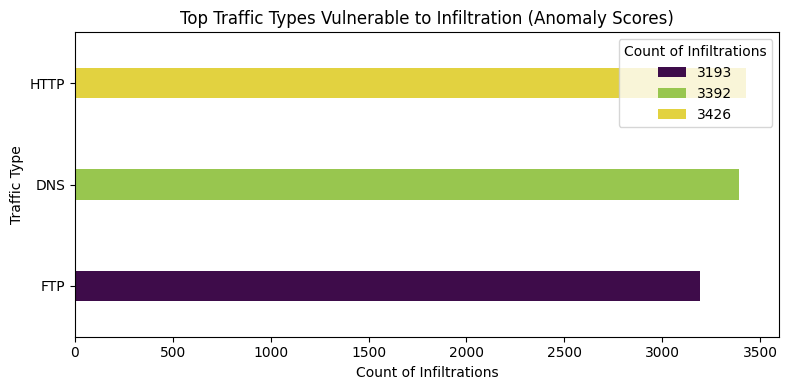

```python
# Plotting the top traffic types vulnerable to infiltration
plt.figure(figsize=(8, 4))
sns.barplot(x='Count of Infiltrations', y='Traffic Type', hue='Count of Infiltrations', data=top_vulnerable_traffic, palette='viridis', dodge=False, width = 0.3)
plt.xlabel('Count of Infiltrations')
plt.ylabel('Traffic Type')
plt.title('Top Traffic Types Vulnerable to Infiltration (Anomaly Scores)')
plt.tight_layout()
plt.show()
```

#### Calculate the threshold as the 95th percentile of 'Anomaly Scores'

```python
# Calculate the threshold as the 95th percentile of 'Anomaly Scores'
threshold = df['Anomaly Scores'].quantile(0.95)
print(f"Threshold for Anomaly Scores: {threshold}\n")

# Filter data where 'Anomaly Scores' exceed the threshold
infiltration_data = df[df['Anomaly Scores'] > threshold]

# Display the first few rows of filtered data to verify
display(infiltration_data.head(3))
```

```
Threshold for Anomaly Scores: 94.87
```

|  | Timestamp | Source IP Address | Destination IP Address | Source Port | Destination Port | Protocol | Packet Length | Packet Type | Traffic Type | Payload Data | ... | Geo-location Data | Proxy Information | Firewall Logs | IDS/IPS Alerts | Log Source | Severity Level Numeric | Month | Year | Browser | Device/OS |
| --- | --- | --- | --- | --- | --- | --- | --- | --- | --- | --- | --- | --- | --- | --- | --- | --- | --- | --- | --- | --- | --- |
| 23 | 2023-09-15 15:43:03 | 46.236.76.78 | 68.194.124.162 | 40832 | 28015 | UDP | 118 | Data | HTTP | Esse porro corrupti. Iusto magnam sunt dolorem... | ... | Chandrapur, Chhattisgarh | 50.108.129.83 | No logs | No alerts | Firewall | 2 | 9 | 2023 | Mozilla | Windows |
| 46 | 2023-05-16 13:01:56 | 170.211.138.30 | 172.97.181.148 | 25022 | 6593 | TCP | 554 | Control | DNS | Voluptate mollitia cupiditate necessitatibus n... | ... | Amravati, Kerala | 95.170.137.42 | Log Data | Alert Data | Firewall | 3 | 5 | 2023 | Mozilla | iPod |
| 76 | 2020-03-09 20:24:39 | 46.229.143.176 | 218.214.206.217 | 54052 | 10368 | ICMP | 686 | Control | DNS | Voluptatibus nemo doloribus sint. Laudantium m... | ... | Gopalpur, Andhra Pradesh | No proxy | No logs | No alerts | Server | 1 | 3 | 2020 | Mozilla | Windows |

3 rows × 30 columns

```python
# Group by 'Traffic Type' and count the number of occurrences
vulnerable_traffic_counts = infiltration_data['Traffic Type'].value_counts()

# Convert the result to a DataFrame for better readability
vulnerable_traffic_df = pd.DataFrame(vulnerable_traffic_counts).reset_index()
vulnerable_traffic_df.columns = ['Traffic Type', 'Count of Infiltrations']

# Display the top 10 vulnerable traffic types by number of infiltrations
top_vulnerable_traffic = vulnerable_traffic_df.head(10)
print(top_vulnerable_traffic)
```

```
  Traffic Type  Count of Infiltrations
0         HTTP                     688
1          DNS                     659
2          FTP                     651
```

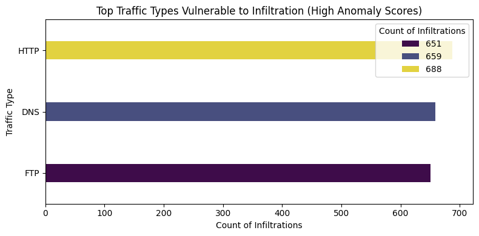

```python
# Plotting the top traffic types vulnerable to infiltration
plt.figure(figsize=(8, 4))
sns.barplot(x='Count of Infiltrations', y='Traffic Type', hue='Count of Infiltrations', data=top_vulnerable_traffic, palette='viridis', dodge=False, width = 0.3)
plt.xlabel('Count of Infiltrations')
plt.ylabel('Traffic Type')
plt.title('Top Traffic Types Vulnerable to Infiltration (High Anomaly Scores)')
plt.tight_layout()
plt.show()
```

#### Top Devices/OS Vulnerable to Cyber Attacks

```python
# Filter data for cyber attacks based on relevant columns
cyber_attacks_data = df[df['Action Taken'].str.contains('Blocked', case=False, na=False)]

# Group by 'Device/OS' and count the number of occurrences
vulnerable_devices_os_counts = cyber_attacks_data['Device/OS'].value_counts()

# Convert the result to a DataFrame for better readability
vulnerable_devices_os_df = pd.DataFrame(vulnerable_devices_os_counts).reset_index()
vulnerable_devices_os_df.columns = ['Device/OS', 'Count of Cyber Attacks']

# Display the top 10 vulnerable devices/OS by number of cyber attacks
top_vulnerable_devices_os = vulnerable_devices_os_df.head(10)
print(top_vulnerable_devices_os)
```

```
   Device/OS  Count of Cyber Attacks
0    Windows                    6072
1      Linux                    2972
2  Macintosh                    1959
3       iPod                     914
4    Android                     559
5     iPhone                     544
6       iPad                     509
```

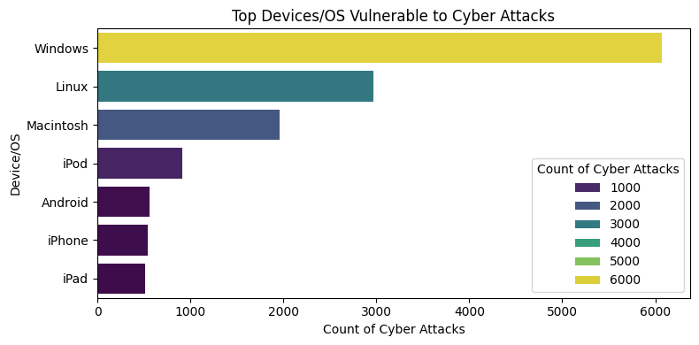

```python
# Plotting the top devices/OS vulnerable to cyber attacks
plt.figure(figsize=(8, 4))
sns.barplot(x='Count of Cyber Attacks', y='Device/OS', hue='Count of Cyber Attacks', data=top_vulnerable_devices_os, palette='viridis', dodge=False)
plt.xlabel('Count of Cyber Attacks')
plt.ylabel('Device/OS')
plt.title('Top Devices/OS Vulnerable to Cyber Attacks')
plt.tight_layout()
plt.show()
```

```python
df.nunique()
```

```
Timestamp                 39997
Source IP Address         40000
Destination IP Address    40000
Source Port               29761
Destination Port          29895
Protocol                      3
Packet Length              1437
Packet Type                   2
Traffic Type                  3
Payload Data              40000
Malware Indicators            2
Anomaly Scores             9826
Alerts/Warnings               2
Attack Type                   3
Attack Signature              2
Action Taken                  3
Severity Level                3
User Information          32389
Device Information        32104
Network Segment               3
Geo-location Data          8723
Proxy Information         20149
Firewall Logs                 2
IDS/IPS Alerts                2
Log Source                    2
Severity Level Numeric        3
Month                        12
Year                          4
Browser                       2
Device/OS                     7
dtype: int64
```

### Model

```python
df.head(2)
```

|  | Timestamp | Source IP Address | Destination IP Address | Source Port | Destination Port | Protocol | Packet Length | Packet Type | Traffic Type | Payload Data | ... | Geo-location Data | Proxy Information | Firewall Logs | IDS/IPS Alerts | Log Source | Severity Level Numeric | Month | Year | Browser | Device/OS |
| --- | --- | --- | --- | --- | --- | --- | --- | --- | --- | --- | --- | --- | --- | --- | --- | --- | --- | --- | --- | --- | --- |
| 0 | 2023-05-30 06:33:58 | 103.216.15.12 | 84.9.164.252 | 31225 | 17616 | ICMP | 503 | Data | HTTP | Qui natus odio asperiores nam. Optio nobis ius... | ... | Jamshedpur, Sikkim | 150.9.97.135 | Log Data | No alerts | Server | 1 | 5 | 2023 | Mozilla | Windows |
| 1 | 2020-08-26 07:08:30 | 78.199.217.198 | 66.191.137.154 | 17245 | 48166 | ICMP | 1174 | Data | HTTP | Aperiam quos modi officiis veritatis rem. Omni... | ... | Bilaspur, Nagaland | No proxy | Log Data | No alerts | Firewall | 1 | 8 | 2020 | Mozilla | Windows |

2 rows × 30 columns

```python
# print(y_train.value_counts(normalize=True))
# print(y_test.value_counts(normalize=True))
```

```python
df.columns
```

```
Index(['Timestamp', 'Source IP Address', 'Destination IP Address',
       'Source Port', 'Destination Port', 'Protocol', 'Packet Length',
       'Packet Type', 'Traffic Type', 'Payload Data', 'Malware Indicators',
       'Anomaly Scores', 'Alerts/Warnings', 'Attack Type', 'Attack Signature',
       'Action Taken', 'Severity Level', 'User Information',
       'Device Information', 'Network Segment', 'Geo-location Data',
       'Proxy Information', 'Firewall Logs', 'IDS/IPS Alerts', 'Log Source',
       'Severity Level Numeric', 'Month', 'Year', 'Browser', 'Device/OS'],
      dtype='object')
```

```python
# Setting features and target columns
features = ['Source Port', 'Destination Port', 'Protocol', 'Packet Length',
        'Packet Type', 'Traffic Type', 'Malware Indicators',
        'Anomaly Scores', 'Alerts/Warnings', 'Attack Type', 'Attack Signature',
        'Action Taken', 'Network Segment', 'Firewall Logs', 'IDS/IPS Alerts', 'Log Source',
        'Month', 'Year', 'Browser', 'Device/OS']

# Target variable
target = 'Severity Level Numeric'

# Creating X and y variables
X = df[features]
y = df[target]
```

```python
y.value_counts()
```

```
Severity Level Numeric
2    13435
3    13382
1    13183
Name: count, dtype: int64
```

```python
object_cols = []
for col in X.columns:
    if X[col].dtypes == 'object':
        object_cols.append(col)
object_cols
```

```
['Protocol',
 'Packet Type',
 'Traffic Type',
 'Malware Indicators',
 'Alerts/Warnings',
 'Attack Type',
 'Attack Signature',
 'Action Taken',
 'Network Segment',
 'Firewall Logs',
 'IDS/IPS Alerts',
 'Log Source',
 'Browser',
 'Device/OS']
```

```python
X.head()
```

|  | Source Port | Destination Port | Protocol | Packet Length | Packet Type | Traffic Type | Malware Indicators | Anomaly Scores | Alerts/Warnings | Attack Type | Attack Signature | Action Taken | Network Segment | Firewall Logs | IDS/IPS Alerts | Log Source | Month | Year | Browser | Device/OS |
| --- | --- | --- | --- | --- | --- | --- | --- | --- | --- | --- | --- | --- | --- | --- | --- | --- | --- | --- | --- | --- |
| 0 | 31225 | 17616 | ICMP | 503 | Data | HTTP | IoC Detected | 28.67 | No alerts | Malware | Known Pattern B | Logged | Segment A | Log Data | No alerts | Server | 5 | 2023 | Mozilla | Windows |
| 1 | 17245 | 48166 | ICMP | 1174 | Data | HTTP | IoC Detected | 51.50 | No alerts | Malware | Known Pattern A | Blocked | Segment B | Log Data | No alerts | Firewall | 8 | 2020 | Mozilla | Windows |
| 2 | 16811 | 53600 | UDP | 306 | Control | HTTP | IoC Detected | 87.42 | Alert Triggered | DDoS | Known Pattern B | Ignored | Segment C | Log Data | Alert Data | Firewall | 11 | 2022 | Mozilla | Windows |
| 3 | 20018 | 32534 | UDP | 385 | Data | HTTP | Not detected | 15.79 | Alert Triggered | Malware | Known Pattern B | Blocked | Segment B | No logs | Alert Data | Firewall | 7 | 2023 | Mozilla | Macintosh |
| 4 | 6131 | 26646 | TCP | 1462 | Data | DNS | Not detected | 0.52 | Alert Triggered | DDoS | Known Pattern B | Blocked | Segment C | No logs | Alert Data | Firewall | 7 | 2023 | Mozilla | Windows |

```python
X.shape, y.shape
```

```
((40000, 20), (40000,))
```

```python
# Label encoding and splitting the datasets using train_test_split
import pandas as pd
from sklearn.preprocessing import LabelEncoder, StandardScaler
from sklearn.model_selection import train_test_split

#Train test split of X and y
X_train, X_test, y_train, y_test = train_test_split(X, y, stratify=y, test_size=0.2, random_state=42)
print("X_train :", X_train.shape)
print("X_test :", X_test.shape)
print("y_train :", y_train.shape)
print("y_test :", y_test.shape)

label_encoders = {col: LabelEncoder() for col in object_cols}

# Apply label encoding to the specified columns in the training set
for col in object_cols:
    X_train[col] = label_encoders[col].fit_transform(X_train[col].astype(str))

# Apply label encoding to the specified columns in the testing set
for col in object_cols:
    # Use the same encoder fitted on the training set
    X_test[col] = label_encoders[col].transform(X_test[col].astype(str))
```

```
X_train : (32000, 20)
X_test : (8000, 20)
y_train : (32000,)
y_test : (8000,)
```

```python
# Normalize/scale features
scaler = StandardScaler()
X_train_scaled = scaler.fit_transform(X_train)
X_test_scaled = scaler.transform(X_test)
```

```python
X_train.head()
```

|  | Source Port | Destination Port | Protocol | Packet Length | Packet Type | Traffic Type | Malware Indicators | Anomaly Scores | Alerts/Warnings | Attack Type | Attack Signature | Action Taken | Network Segment | Firewall Logs | IDS/IPS Alerts | Log Source | Month | Year | Browser | Device/OS |
| --- | --- | --- | --- | --- | --- | --- | --- | --- | --- | --- | --- | --- | --- | --- | --- | --- | --- | --- | --- | --- |
| 6927 | 47034 | 26651 | 1 | 930 | 1 | 2 | 0 | 23.31 | 1 | 2 | 0 | 2 | 2 | 1 | 1 | 0 | 7 | 2022 | 0 | 6 |
| 12650 | 64484 | 49466 | 1 | 678 | 1 | 2 | 1 | 2.06 | 1 | 1 | 1 | 0 | 0 | 0 | 0 | 0 | 6 | 2020 | 0 | 5 |
| 39720 | 28862 | 63649 | 0 | 1161 | 1 | 2 | 1 | 71.68 | 1 | 2 | 1 | 1 | 1 | 0 | 1 | 0 | 7 | 2022 | 1 | 1 |
| 36932 | 11398 | 15331 | 0 | 577 | 1 | 1 | 1 | 1.06 | 1 | 0 | 1 | 1 | 0 | 0 | 1 | 0 | 8 | 2022 | 0 | 6 |
| 7559 | 5483 | 48569 | 1 | 1410 | 0 | 1 | 1 | 68.98 | 0 | 1 | 0 | 1 | 1 | 1 | 0 | 0 | 10 | 2021 | 1 | 1 |

```python
X_test.head()
```

|  | Source Port | Destination Port | Protocol | Packet Length | Packet Type | Traffic Type | Malware Indicators | Anomaly Scores | Alerts/Warnings | Attack Type | Attack Signature | Action Taken | Network Segment | Firewall Logs | IDS/IPS Alerts | Log Source | Month | Year | Browser | Device/OS |
| --- | --- | --- | --- | --- | --- | --- | --- | --- | --- | --- | --- | --- | --- | --- | --- | --- | --- | --- | --- | --- |
| 20395 | 60218 | 63815 | 0 | 1320 | 0 | 2 | 0 | 72.87 | 0 | 2 | 1 | 1 | 2 | 0 | 1 | 0 | 10 | 2021 | 0 | 3 |
| 27775 | 54158 | 18443 | 0 | 1371 | 0 | 1 | 0 | 0.23 | 1 | 2 | 0 | 1 | 0 | 1 | 1 | 1 | 6 | 2021 | 0 | 3 |
| 7228 | 55390 | 24529 | 2 | 881 | 0 | 0 | 1 | 7.03 | 0 | 2 | 0 | 0 | 1 | 0 | 0 | 1 | 1 | 2022 | 0 | 3 |
| 24237 | 60398 | 3733 | 1 | 960 | 1 | 2 | 0 | 25.46 | 0 | 1 | 0 | 1 | 2 | 0 | 1 | 0 | 10 | 2020 | 0 | 3 |
| 22705 | 45224 | 21229 | 2 | 1168 | 0 | 2 | 0 | 7.48 | 1 | 0 | 1 | 0 | 0 | 0 | 0 | 0 | 10 | 2022 | 0 | 1 |

```python
# Checking if dataset is splitted equally
print(y_train.value_counts(normalize=True))
print(y_test.value_counts(normalize=True))
```

```
Severity Level Numeric
2    0.335875
3    0.334562
1    0.329562
Name: proportion, dtype: float64
Severity Level Numeric
2    0.335875
3    0.334500
1    0.329625
Name: proportion, dtype: float64
```

#### Random forest classifier

```python
from sklearn.ensemble import RandomForestClassifier
from sklearn.metrics import classification_report, accuracy_score

# Initialize and train the model
rfc = RandomForestClassifier(random_state=42)
rfc.fit(X_train, y_train)

# Predict on the test set
y_pred_rfc = rfc.predict(X_test)
cm_rfc = confusion_matrix(y_test, y_pred_rfc)

# Evaluate the model
print(cm_rfc)
print(classification_report(y_test, y_pred_rfc))
```

```
[[793 951 893]
 [899 932 856]
 [864 952 860]]
              precision    recall  f1-score   support

           1       0.31      0.30      0.31      2637
           2       0.33      0.35      0.34      2687
           3       0.33      0.32      0.33      2676

    accuracy                           0.32      8000
   macro avg       0.32      0.32      0.32      8000
weighted avg       0.32      0.32      0.32      8000
```

```python
# Define the parameter grid
param_grid = {
    'n_estimators': [50, 100, 200],
    'max_depth': [None, 10, 20, 30],
    'min_samples_split': [2, 5, 10, 15, 20],
    'min_samples_leaf': [1, 2, 4],
    'max_features': [None, 'sqrt', 'log2'],
    'bootstrap': [True, False]
}


# Set up cross-validation
cv = StratifiedKFold(n_splits=5, shuffle=True, random_state=42)

# Set up the scorer
f1_macro_scorer = make_scorer(f1_score, average='macro')

# Set up GridSearchCV
grid_search = GridSearchCV(
    estimator=rfc,
    param_grid=param_grid,
    scoring=f1_macro_scorer,
    cv=cv,
    n_jobs=-1,
    verbose=0
)

# Fit GridSearchCV to the training data
grid_search.fit(X_train, y_train)

# Print the best parameters and best score
print("Best Parameters:", grid_search.best_params_)
print("Best F1 Score:", grid_search.best_score_)

# You can use the best estimator for predictions
best_rfc = grid_search.best_estimator_
y_pred_rfc_cv = best_rfc.predict(X_test)

# Evaluate the model on the test data
from sklearn.metrics import classification_report
print(classification_report(y_test, y_pred_rfc_cv))
```

```
Best Parameters: {'bootstrap': True, 'max_depth': 20, 'max_features': 'sqrt', 'min_samples_leaf': 2, 'min_samples_split': 20, 'n_estimators': 50}
Best F1 Score: 0.3381969988281689
              precision    recall  f1-score   support

           1       0.34      0.31      0.32      2637
           2       0.33      0.35      0.34      2687
           3       0.33      0.34      0.33      2676

    accuracy                           0.33      8000
   macro avg       0.33      0.33      0.33      8000
weighted avg       0.33      0.33      0.33      8000
```

```python
# importances = rfc.feature_importances_
# feature_names = X.columns
# feature_importance_df = pd.DataFrame({'Feature': feature_names, 'Importance': importances})
# feature_importance_df = feature_importance_df.sort_values(by='Importance', ascending=False)

# plt.figure(figsize=(10, 6))
# sns.barplot(x='Importance', y='Feature', data=feature_importance_df.head(30))
# plt.title('Top 10 Feature Importances')
# plt.show()
```

#### Decision tree classifier

```python
# Decision Tree Classifier
from sklearn.tree import DecisionTreeClassifier

#Training the linear regression model
dtc = DecisionTreeClassifier(random_state=42)
dtc.fit(X_train, y_train)

# Predict on the test set
y_pred_dtc = dtc.predict(X_test)
cm_dtc = confusion_matrix(y_test, y_pred_dtc)

# Evaluate the model
print(cm_dtc)
print(classification_report(y_test, y_pred_dtc))
```

```
[[866 862 909]
 [861 914 912]
 [843 930 903]]
              precision    recall  f1-score   support

           1       0.34      0.33      0.33      2637
           2       0.34      0.34      0.34      2687
           3       0.33      0.34      0.33      2676

    accuracy                           0.34      8000
   macro avg       0.34      0.34      0.34      8000
weighted avg       0.34      0.34      0.34      8000
```

```python
# Define the parameter grid
param_grid = {
    'criterion': ['gini', 'entropy'],
    'splitter': ['best', 'random'],
    'max_depth': [None, 10, 20, 30],
    'min_samples_split': [2, 5, 10],
    'min_samples_leaf': [1, 2, 4],
    'max_features': [None, 'sqrt', 'log2']
}


# Set up cross-validation
cv = StratifiedKFold(n_splits=5, shuffle=True, random_state=42)

# Set up the scorer
f1_macro_scorer = make_scorer(f1_score, average='macro')

# Set up GridSearchCV
grid_search = GridSearchCV(
    estimator=dtc,
    param_grid=param_grid,
    scoring=f1_macro_scorer,
    cv=cv,
    n_jobs=-1,
    verbose=0
)

# Fit GridSearchCV to the training data
grid_search.fit(X_train, y_train)

# Print the best parameters and best score
print("Best Parameters:", grid_search.best_params_)
print("Best F1 Score:", grid_search.best_score_)

# You can use the best estimator for predictions
best_dtc = grid_search.best_estimator_
y_pred_dtc_cv = best_dtc.predict(X_test)

# Evaluate the model on the test data
from sklearn.metrics import classification_report
print(classification_report(y_test, y_pred_dtc_cv))
```

```
Best Parameters: {'criterion': 'gini', 'max_depth': None, 'max_features': None, 'min_samples_leaf': 2, 'min_samples_split': 10, 'splitter': 'random'}
Best F1 Score: 0.34161015633660713
              precision    recall  f1-score   support

           1       0.34      0.38      0.36      2637
           2       0.33      0.32      0.33      2687
           3       0.34      0.31      0.32      2676

    accuracy                           0.34      8000
   macro avg       0.34      0.34      0.34      8000
weighted avg       0.34      0.34      0.34      8000
```

#### Logistic regression

```python
from sklearn.linear_model import LogisticRegression

# Initialize and train the model
lr = LogisticRegression(random_state=42)
lr.fit(X_train, y_train)

# Predict on the test set
y_pred_lr = lr.predict(X_test)
cm_lr = confusion_matrix(y_test, y_pred_lr)

# Evaluate the model
print(cm_lr)
print(classification_report(y_test, y_pred_lr))
```

```
[[ 450 1442  745]
 [ 505 1426  756]
 [ 513 1409  754]]
              precision    recall  f1-score   support

           1       0.31      0.17      0.22      2637
           2       0.33      0.53      0.41      2687
           3       0.33      0.28      0.31      2676

    accuracy                           0.33      8000
   macro avg       0.32      0.33      0.31      8000
weighted avg       0.32      0.33      0.31      8000
```

```python
# # Define the parameter grid
# param_grid = {
#     'penalty': ['l1', 'l2', 'elasticnet', 'none'],
#     'C': [0.01, 0.1, 1, 10, 100],
#     'solver': ['lbfgs', 'liblinear', 'saga'],
#     'max_iter': [100, 200, 300]
# }


# # Set up cross-validation
# cv = StratifiedKFold(n_splits=5, shuffle=True, random_state=42)

# # Set up the scorer
# f1_macro_scorer = make_scorer(f1_score, average='macro')

# # Set up GridSearchCV
# grid_search = GridSearchCV(
#     estimator=lr,
#     param_grid=param_grid,
#     scoring=f1_macro_scorer,
#     cv=cv,
#     n_jobs=-1,
#     verbose=0
# )

# # Fit GridSearchCV to the training data
# grid_search.fit(X_train_scaled, y_train)

# # Print the best parameters and best score
# print("Best Parameters:", grid_search.best_params_)
# print("Best F1 Score:", grid_search.best_score_)

# # You can use the best estimator for predictions
# best_lr = grid_search.best_estimator_
# y_pred_lr_cv = best_lr.predict(X_test_scaled)

# # Evaluate the model on the test data
# from sklearn.metrics import classification_report
# print(classification_report(y_test, y_pred_lr_cv))
```

```python
# Define the parameter grid
param_grid = [
    {
        'penalty': ['elasticnet'],
        'C': [0.01, 0.1, 1, 10],
        'solver': ['saga'],
        'l1_ratio': [0.15, 0.5, 0.85],
        'max_iter': [200, 500, 1000]
    },
    {
        'penalty': [None],
        'solver': ['lbfgs', 'saga'],
        'max_iter': [200, 500, 1000]
    }
]


# Set up cross-validation
cv = StratifiedKFold(n_splits=5, shuffle=True, random_state=42)

# Set up the scorer
f1_macro_scorer = make_scorer(f1_score, average='macro')

# Set up GridSearchCV
grid_search = GridSearchCV(
    estimator=lr,
    param_grid=param_grid,
    scoring=f1_macro_scorer,
    cv=cv,
    n_jobs=-1,
    verbose=0
)

# Fit GridSearchCV to the training data
grid_search.fit(X_train_scaled, y_train)

# Print the best parameters and best score
print("Best Parameters:", grid_search.best_params_)
print("Best F1 Score:", grid_search.best_score_)

# You can use the best estimator for predictions
best_lr = grid_search.best_estimator_
y_pred_lr_cv = best_lr.predict(X_test_scaled)

# Evaluate the model on the test data
from sklearn.metrics import classification_report
print(classification_report(y_test, y_pred_lr_cv))
```

[output not shown]